# TidyTuesday 2018 - Week 27 - US Births

Roberto Preste

2018-10-03

This is my work for week 27 (2018) of the [#TidyTuesday](https://thomasmock.netlify.com/post/tidytuesday-a-weekly-social-data-project-in-r/) project.

A funny dataset for this week’s TidyTuesday: how many babies are born on Friday 13<sup>th</sup> compared to other days?  
The [original article](https://fivethirtyeight.com/features/some-people-are-too-superstitious-to-have-a-baby-on-friday-the-13th/) and data are offered by fivethirtyeight ([here](https://github.com/rudeboybert/fivethirtyeight) is their GitHub profile, where all the raw data can be found).

All code and data can be found in my dedicated GitHub repository MyTidyTuesday.

```r
library(tidyverse)
library(magrittr)
library(lubridate)
library(skimr)
library(RColorBrewer)
```

We will first load the data into R.

```r
df <- read_csv("data/us_births_2000-2014.csv")
head(df)
```

```
## # A tibble: 6 x 5
##    year month date_of_month day_of_week births
##   <dbl> <dbl>         <dbl>       <dbl>  <dbl>
## 1  2000     1             1           6   9083
## 2  2000     1             2           7   8006
## 3  2000     1             3           1  11363
## 4  2000     1             4           2  13032
## 5  2000     1             5           3  12558
## 6  2000     1             6           4  12466
```

## Data Exploration

Let’s check for missing values and other issues.

```r
skim(df)
```

```
## Skim summary statistics
##  n obs: 5479
##  n variables: 5
##
## ── Variable type:numeric ────────────────────────────────────────────────────────────────────────────────────────
##       variable missing complete    n     mean      sd   p0  p25   p50   p75  p100     hist
##         births       0     5479 5479 11350.07 2325.82 5728 8740 12343 13082 16081 ▁▃▂▁▃▇▂▁
##  date_of_month       0     5479 5479    15.73    8.8     1    8    16    23    31 ▇▇▇▇▆▇▇▇
##    day_of_week       0     5479 5479     4       2       1    2     4     6     7 ▇▇▇▇▁▇▇▇
##          month       0     5479 5479     6.52    3.45    1    4     7    10    12 ▇▅▇▃▅▇▅▇
##           year       0     5479 5479  2007       4.32 2000 2003  2007  2011  2014 ▇▇▇▇▅▇▇▇
```

Everything seems to be in order.  
Let’s add another column, `date`, to obtain the proper date from the `year`, `month` and `date_of_month` features.

```r
df %<>%
    mutate(date = as_date(paste(year, month, date_of_month, sep = "-")))
```

```r
df
```

```
## # A tibble: 5,479 x 6
##     year month date_of_month day_of_week births date
##    <dbl> <dbl>         <dbl>       <dbl>  <dbl> <date>
##  1  2000     1             1           6   9083 2000-01-01
##  2  2000     1             2           7   8006 2000-01-02
##  3  2000     1             3           1  11363 2000-01-03
##  4  2000     1             4           2  13032 2000-01-04
##  5  2000     1             5           3  12558 2000-01-05
##  6  2000     1             6           4  12466 2000-01-06
##  7  2000     1             7           5  12516 2000-01-07
##  8  2000     1             8           6   8934 2000-01-08
##  9  2000     1             9           7   7949 2000-01-09
## 10  2000     1            10           1  11668 2000-01-10
## # … with 5,469 more rows
```

I will create a set of colors that I’ll use during this analysis.

```r
pastels <- brewer.pal(4, "Pastel1")
```

## Discussion

Now we can have a quick look at the distribution of births over the years.

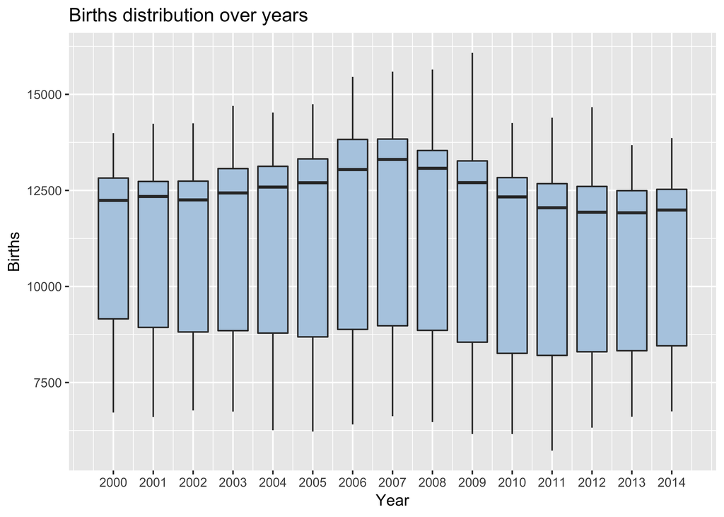

```r
df %>%
    ggplot(aes(x = year, y = births)) +
    geom_boxplot(aes(group = year), fill = pastels[2]) +
    scale_x_continuous(breaks = c(2000:2014)) +
    labs(x = "Year", y = "Births", title = "Births distribution over years")
```

The number of births each year seems to be quite constant, with a small increase in 2006-2008.  
Let’s plot the same distribution over months this time.

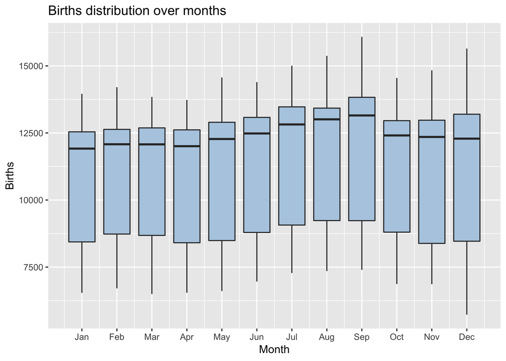

```r
df %>%
    ggplot(aes(x = month, y = births)) +
    geom_boxplot(aes(group = month), fill = pastels[2]) +
    scale_x_continuous(breaks = c(1:12),
                       labels = month.abb) +
    labs(x = "Month", y = "Births", title = "Births distribution over months")
```

It looks like most births are occurring in September; this is quite interesting, and my guess is that this may due to couples being able to *“spend more time together”* during Christmas holidays, if you know what I mean…  
Lastly, let’s view the distribution of births over days of a month.

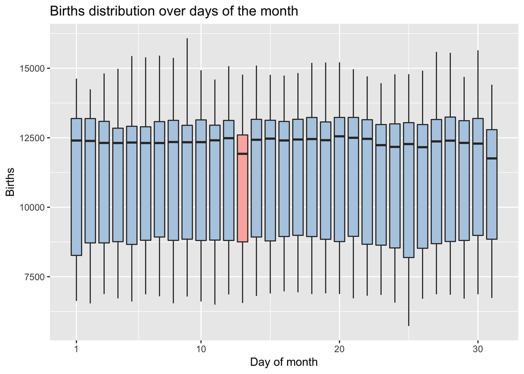

```r
day_colors <- c(rep(pastels[2], 12), pastels[1], rep(pastels[2], 18))
df %>%
    ggplot(aes(x = date_of_month, y = births)) +
    geom_boxplot(aes(group = date_of_month), fill = day_colors) +
    scale_x_continuous(breaks = c(1, 10, 20, 30)) +
    labs(x = "Day of month", y = "Births", title = "Births distribution over days of the month")
```

And there it is! Each 13<sup>th</sup> day the number of births is a bit lower than the other days; the same is true for the 31<sup>st</sup>, but this may be due to months having only 30 days. Let’s explore a bit more by plotting the same per-day distribution splitted by month.

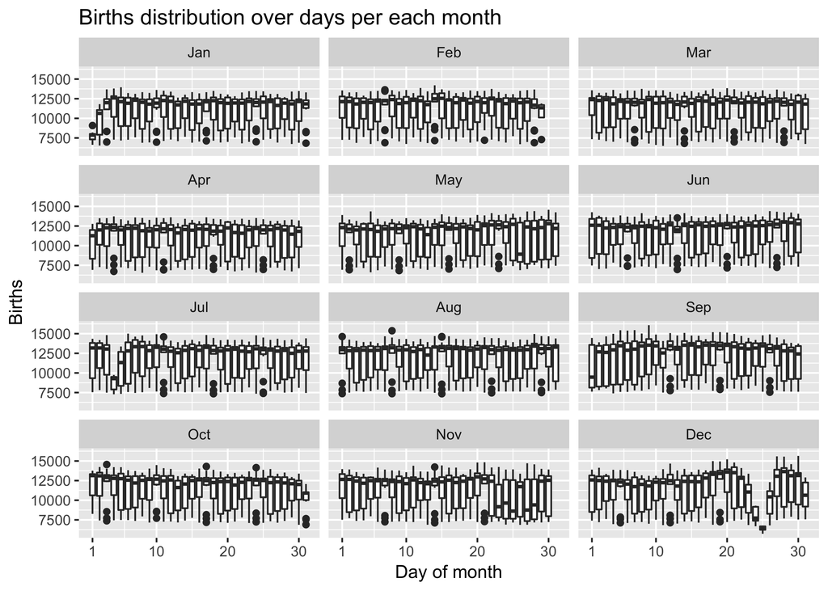

```r
df %>%
    ggplot(aes(x = date_of_month, y = births)) +
    geom_boxplot(aes(group = date_of_month)) +
    facet_wrap(month ~ ., nrow = 4, ncol = 3,
               labeller = function(variable, value) {return(month.abb[value])}) +
    scale_x_continuous(breaks = c(1, 10, 20, 30)) +
    labs(x = "Day of month", y = "Births", title = "Births distribution over days per each month")
```

Although this is quite an ugly plot, we can see that usually every 13<sup>th</sup> of each month few babies are born. The same occurs with national holydays, and this is obvious from the drop in the number of births around Christmas, or on the 4<sup>th</sup> of July, or during the last few days of November for Thanksgiving.

But we haven’t still explored the number of births occurring on Friday 13<sup>th</sup>.  
Let’s first see how birth are distributed over days of the week.

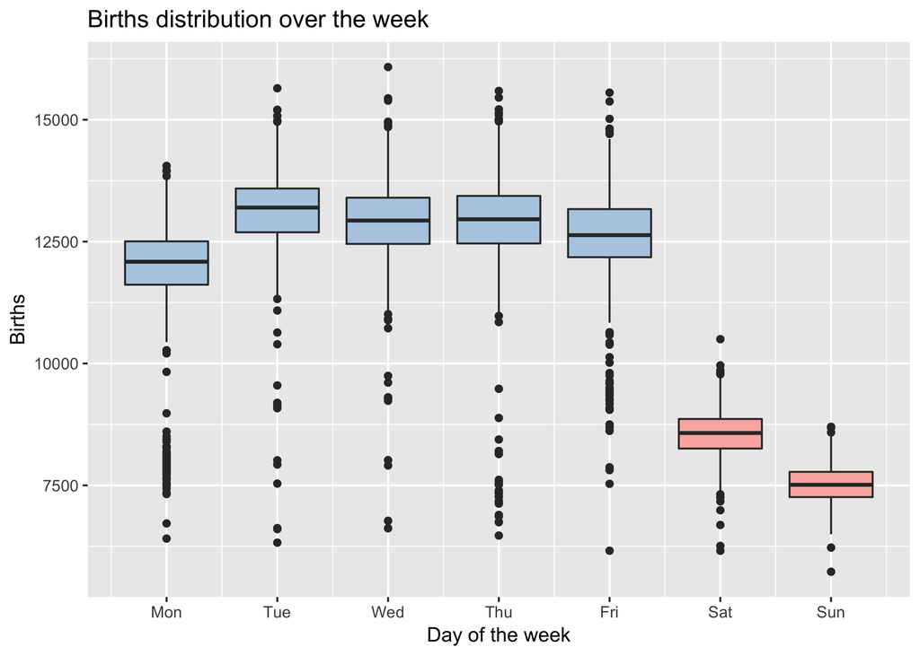

```r
week_colors <- c(rep(pastels[2], 5), rep(pastels[1], 2))
df %>%
    ggplot(aes(x = day_of_week, y = births)) +
    geom_boxplot(aes(group = day_of_week), fill = week_colors) +
    scale_x_continuous(breaks = c(1:7),
                       labels = c("Mon", "Tue", "Wed", "Thu", "Fri", "Sat", "Sun")) +
    labs(x = "Day of the week", y = "Births", title = "Births distribution over the week")
```

We can see a strong dicrease in the number of newborns during the weekends, and this is quite expected.  
Now let’s gather all these information and actually check if Friday 13<sup>th</sup> is really a no-no for delivering babies.

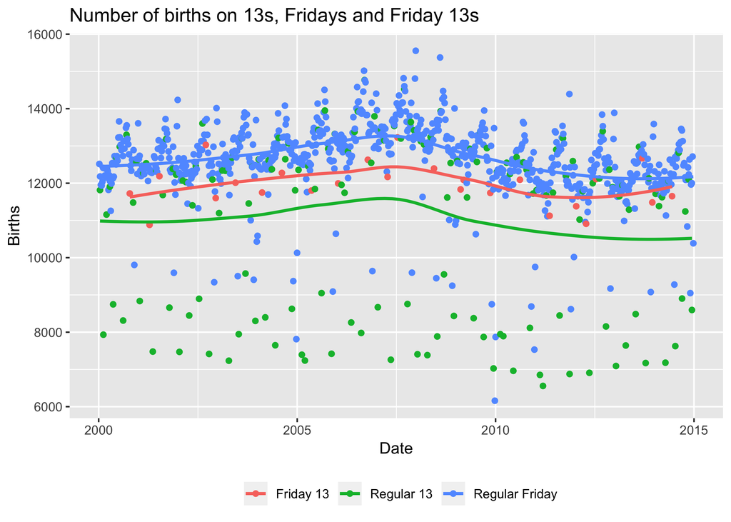

```r
df %>%
    mutate(lucky = case_when(date_of_month == 13 & day_of_week == 5 ~ "Friday 13",
                             date_of_month == 13 & day_of_week != 5 ~ "Regular 13",
                             date_of_month != 13 & day_of_week == 5 ~ "Regular Friday",
                             TRUE ~ "Other")) %>%
    filter(lucky != "Other") %>%
    ggplot(aes(x = date, y = births, color = lucky)) +
    geom_point() +
    geom_smooth(method = "loess", se = F) +
    labs(x = "Date", y = "Births", title = "Number of births on 13s, Fridays and Friday 13s") +
    guides(color = guide_legend(title = NULL)) +
    theme(legend.position = "bottom")
```

From what we see, there is no actual decrease in the number of births on Friday 13<sup>th</sup>, but rather on the 13<sup>th</sup> of each month, regardless of the day of the week.